# Simulation Exercise Exponential Distribution

Daniel Cevallos

21/06/2023

# Overview

The exponential distribution can be simulated in R with rexp(n, lambda) where lambda is the rate parameter. The mean of exponential distribution is 1/lambda and the standard deviation is also 1/lambda. Set lambda = 0.2 for all of the simulations. You will investigate the distribution of averages of 40 exponentials. Note that you will need to do a thousand simulations.

### What is exponential distribution?

From Wikipedia: Exponential distribution describes times between events happening at constant rate lambda with expected value 1/lambda.

This simulation contains:

1. Show the sample mean and compare it to the theoretical mean of the distribution
2. Show how variable the sample is (via variance) and compare it to the theoretical variance of the distribution
3. Show that the distribution is approximately normal

# Simulation

The exponential distribution is simulated with `rexp(n, lambda)`, where lambda is the rate parameter. The mean of exponential distribution and standard deviation is 1/lambda. Lambda is set at 0.2 for all simulations.

### Sample exponential distribution

```r
library(ggplot2)
library(knitr)
set.seed(10000) # for reproducability
nosim <- 1000 # no of simulations
n <- 40 # no of exponentials
lambda <- 0.2 # rate parameter

simdata <- matrix(rexp(nosim * n, rate=lambda), nosim)
sim_mean <- rowMeans(simdata) # row means

# calculate mean, sd and variance of sample exp dist
simdata_mean <- mean(sim_mean)
simdata_sd <- sd(sim_mean)
simdata_var <- var(sim_mean)
t_mean = 1/lambda
t_sd = (1/lambda) * (1/sqrt(n))
t_var = t_sd^2
```

### Sample Mean VS Theoretical Mean

The theoretical mean of the average of samples will be : 1/λ .The following shows that the average from sample means and the theoretical mean are very close.

```r
# calculate mean, df and variance of theoretical exp dist
actual_mean <- simdata_mean
theoretical_mean <- 1/ lambda

result1 <-data.frame("Mean"=c(actual_mean,theoretical_mean),
                     row.names = c("Mean from the samples ","Theoretical mean"))

result1
```

```
##                           Mean
## Mean from the samples  5.00599
## Theoretical mean       5.00000
```

# Histogram of the sample means.

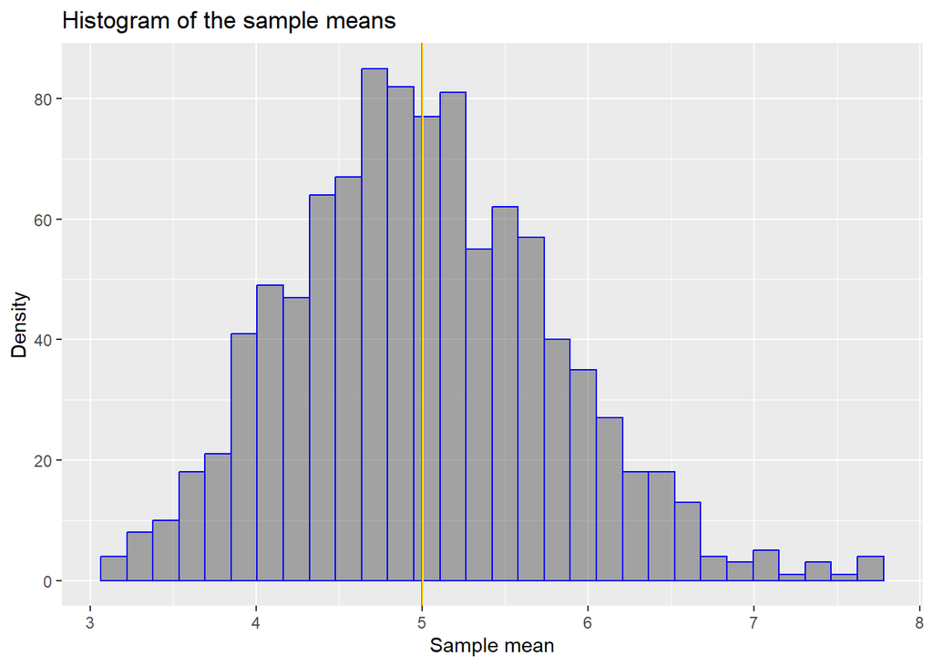

# Comparison between sample and theoretical statistics

```
##          Sample_stats Theoretical_stats         diff
## Mean        5.0059905         5.0000000  0.005990482
## Std         0.7935060         0.7905694  0.002936632
## Variance    0.6296518         0.6250000 -0.004651846
```

# Distribution

## Histogram and Density plot

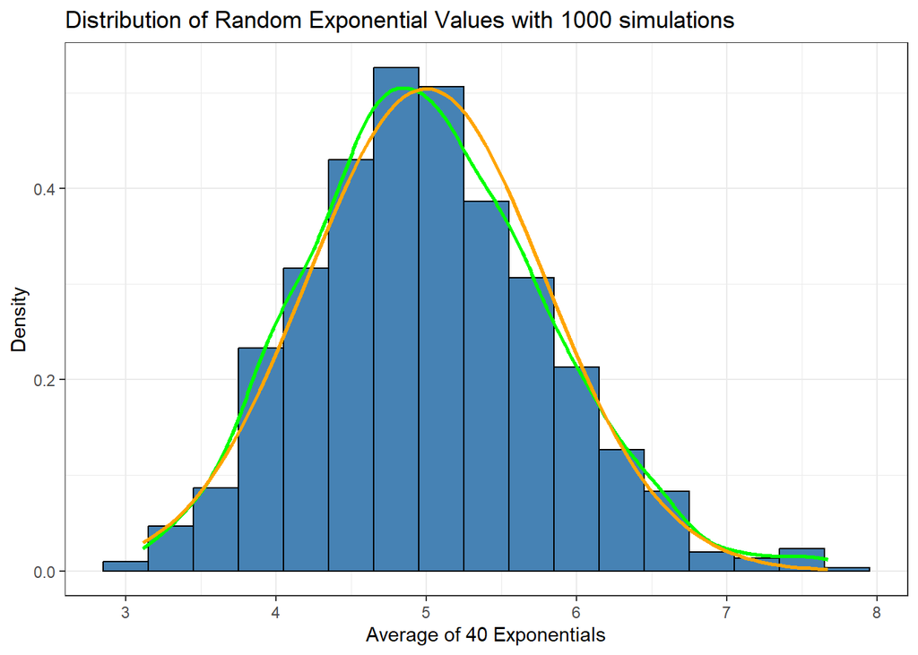

## Q-Q plot

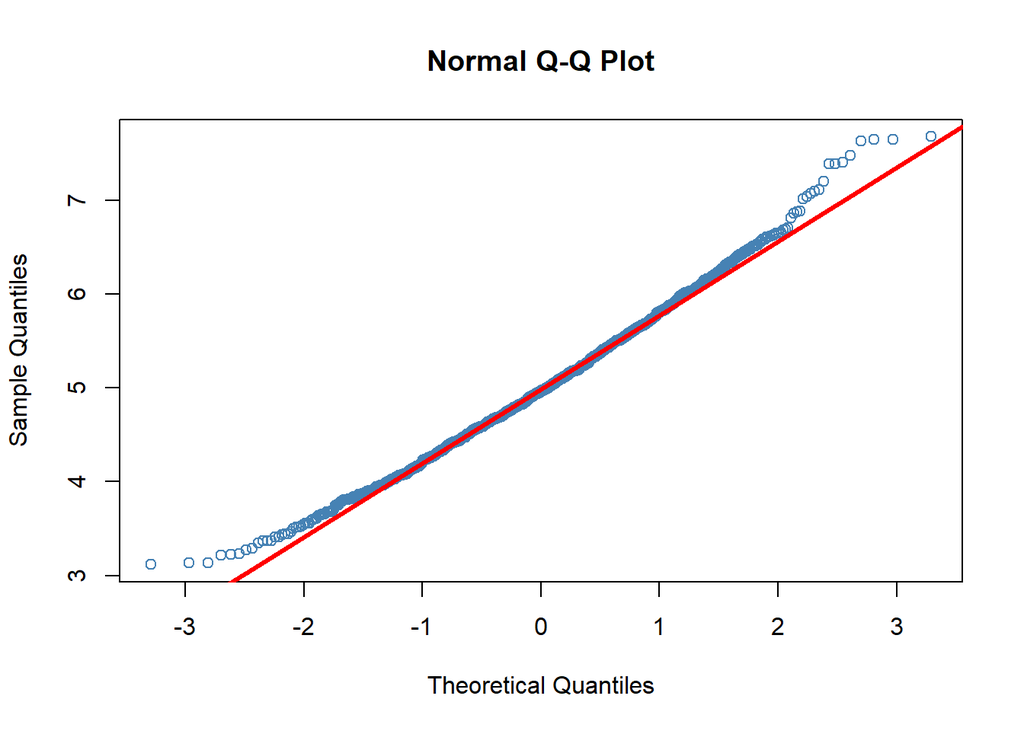

Observing the normal Q-Q plot, we can conclude that the sample distribution approximates the theoretical normal distribution quite closely, with the tails being less normal.

These above listed methods of comparisons show that the distribution is approximately normal.